# Amy Clarke and Emma Reynolds - Salaries in Chicago

### https://amybarbaraclarke.github.io/amyandemma/

## Project Overview

The City of Chicago is one of the largest municipal employers in the US, with thousands of employees working across many departments. But how are these salaries distributed across departments? And does the size of a department determine how big its budget is? Is it possible to build a model to predict a department's total budget from different features?

In this tutorial, we answer those questions through the combination of two publicly available City of Chicago datasets:

1. **Current Employee Names, Salaries, and Position Titles**: Individual-level salary data, Source: [data.gov text](https://catalog.data.gov/dataset/current-employee-names-salaries-and-position-titles)
2. **2026 Budget Ordinance -- Appropriations**: Department-level budget allocations, Source: [City of Chicago Data Portal](https://data.cityofchicago.org/Administration-Finance/Budget-2026-Budget-Ordinance-Appropriations/6694-f78c/data_preview)

This reproducible notebook addresses data ingestion & cleaning, exploratory analysis, feature engineering and predictive modeling. To follow along, click the source links above, download the two datasets and upload them to your content folder!

### Motivation and Research Questions Addressed:

Amy and I wanted to look at Chicago specifically, because we are both from Chicago and working there this summer. In a year, we will graduate and both want to work in the city, so we thought this project would be a fun way for us to start looking at departments to work in and their salary variabilites. We had a couple of different questions:

| # | Question |
| --- | --- |
| **Q1** | Does salary vary more within departments or across departments? |
| **Q2** | Are similar job titles paid differently depending on the department? |
| **Q3** | What are the range, mean, and median salaries across each department? |
| **Q4** | How spread out are salaries within each department? |
| **Q5** | Is there a relationship between average salary and budget per employee? |
| **Q6** | Does department size (employee count) determine total department budget? |
| **Q7** | Can a department's total budget be predicted from different features? |

### Collaboration Plan:

Amy and Emma are in the same major and share classes. We met twice a week, Mondays after Data Science and Thursdays at 12:30, and coordinated using a shared GitHub repository, as well as a shared Google Colab workspace. We have worked together before on computer science projects, so our working style and communication are strong. Amy led ETL and EDA, Emma let modeling and writeup, with both reviewing all sections together. In this tutorial, we used Python, pandas, maplotlib, scikit-learn, and Google Colab.

```python
#Import the needed libraries
import pandas as pd
import matplotlib
import matplotlib.pyplot as plt
import numpy as np
import io

#Import tools for colab
from google.colab import files
from google.colab import drive

# Mount Google Drive so the notebook can access files
drive.mount('/content/drive')
```

## Final Research Question

This project investigates whether employee compensation patterns help explain how Chicago city departments receive and use public funding. Specifically, we ask:

**Can department-level salary statistics and employee counts help predict total departmental budget or budget per employee?**

This question matters because city budgets reflect public priorities. By comparing salary data with budget appropriations, we can better understand whether departments with higher average salaries, more employees, or wider salary distributions receive larger budgets. This also helps identify the limits of using salary data alone to explain public budgeting decisions.

### Loading the Dataset

Here we will load in the Chicago Employee dataset into a pandas dataframe. The dataset includes emplyee names, job titles, department, full or part-time, salary/hourly, typical hours, annual salary, hourly rate. We then preview the first 50 rows of the dataset to understand the structure and variables included.

```python
#Read the dataset into a dataframe
current = pd.read_csv('/content/Current_Employee_Names__Salaries__and_Position_Titles (1).csv')

#Inspect data types
print(current.dtypes)

#Check missing values
print(current.isnull().sum())

#Preview first 50 rows
current.head(50)
```

```
Name                  object
Job Titles            object
Department            object
Full or Part-Time     object
Salary or Hourly      object
Typical Hours        float64
Annual Salary        float64
Hourly Rate          float64
dtype: object
Name                     0
Job Titles               0
Department               0
Full or Part-Time        0
Salary or Hourly         0
Typical Hours        24950
Annual Salary         6831
Hourly Rate          24950
dtype: int64
```

|  | Name | Job Titles | Department | Full or Part-Time | Salary or Hourly | Typical Hours | Annual Salary | Hourly Rate |
| --- | --- | --- | --- | --- | --- | --- | --- | --- |
| 0 | SANFRATELLO, VINCENT A | BRICKLAYER | DEPARTMENT OF WATER MANAGEMENT | F | HOURLY | 40.0 | NaN | 53.06 |
| 1 | TILLMAN, NELSON P | SANITATION LABORER | DEPARTMENT OF STREETS AND SANITATION | F | HOURLY | 40.0 | NaN | 47.79 |
| 2 | WALL, TAHARI L | CONSTRUCTION LABORER | DEPARTMENT OF WATER MANAGEMENT | F | HOURLY | 40.0 | NaN | 51.40 |
| 3 | HEHIR, CONOR R | ASST CHIEF OPERATING ENGINEER | DEPARTMENT OF WATER MANAGEMENT | F | HOURLY | 40.0 | NaN | 68.26 |
| 4 | BURFORD, JAMES L | CEMENT FINISHER | DEPARTMENT OF WATER MANAGEMENT | F | HOURLY | 40.0 | NaN | 53.10 |
| 5 | MENDOZA, RALPH D | SENIOR HELP DESK TECHNICIAN | CHICAGO PUBLIC LIBRARY | F | SALARY | NaN | 134916.00 | NaN |
| 6 | DAVIS, TASHA | FIRE MARSHAL-EMT | CHICAGO FIRE DEPARTMENT | F | SALARY | NaN | 122136.00 | NaN |
| 7 | LEE, AARON J | DEPUTY COMMISSIONER | DEPARTMENT OF BUSINESS AFFAIRS AND CONSUMER PR... | F | SALARY | NaN | 157332.00 | NaN |
| 8 | JOYCE, MARGARET A | POLICE OFFICER / FLD TRNG OFFICER | CHICAGO POLICE DEPARTMENT | F | SALARY | NaN | 114828.00 | NaN |
| 9 | LAVELLE, JOHN E | OPERATING ENGINEER-GROUP C | DEPARTMENT OF WATER MANAGEMENT | F | HOURLY | 40.0 | NaN | 58.95 |
| 10 | JACKSON, LEMONT T | CONSTRUCTION LABORER | DEPARTMENT OF WATER MANAGEMENT | F | HOURLY | 40.0 | NaN | 51.40 |
| 11 | LAZAAR, GEORGE S | SENIOR HELP DESK TECHNICIAN | CHICAGO PUBLIC LIBRARY | F | SALARY | NaN | 134916.00 | NaN |
| 12 | ROBINSON, GENAE A | PUBLIC RELATIONS REPRESENTATIVE III | CHICAGO PUBLIC LIBRARY | F | SALARY | NaN | 134916.00 | NaN |
| 13 | LYNCH, JAMES P | OPERATING ENGINEER-GROUP C | DEPARTMENT OF WATER MANAGEMENT | F | HOURLY | 40.0 | NaN | 58.95 |
| 14 | SIMONELLI, CONNIE J | HUMAN RELATIONS INVESTIGATOR II | CHICAGO COMMISSION ON HUMAN RELATIONS | F | SALARY | NaN | 122700.00 | NaN |
| 15 | REDDITT, CRYSTAL D | ALDERMANIC AIDE | CITY COUNCIL | P | HOURLY | 20.0 | NaN | 30.00 |
| 16 | ROBERTSON, SCOTT M | OPERATING ENGINEER-GROUP C | DEPARTMENT OF WATER MANAGEMENT | F | HOURLY | 40.0 | NaN | 58.95 |
| 17 | MORIARTY, DANIEL N | OPERATING ENGINEER-GROUP C | DEPARTMENT OF WATER MANAGEMENT | F | HOURLY | 40.0 | NaN | 58.95 |
| 18 | VAUGHAN, GABRIELLE N | ANIMAL CONTROL OFFICER | CHICAGO ANIMAL CARE AND CONTROL | F | SALARY | NaN | 56328.00 | NaN |
| 19 | ROGERS, BRIDGET M | MOTOR TRUCK DRIVER | CHICAGO DEPARTMENT OF TRANSPORTATION | F | HOURLY | 40.0 | NaN | 48.73 |
| 20 | HARPER, LEXES | WATER CHEMIST II | DEPARTMENT OF WATER MANAGEMENT | F | SALARY | NaN | 74160.00 | NaN |
| 21 | ROGERS, MICHAEL A | ASST CHIEF OPERATING ENGINEER | CHICAGO DEPARTMENT OF AVIATION | F | HOURLY | 40.0 | NaN | 68.26 |
| 22 | ZLOTOW, JENNIFER M | ASST CORPORATION COUNSEL SUPVSR | DEPARTMENT OF LAW | F | SALARY | NaN | 164100.00 | NaN |
| 23 | CUEVA, ROBERTO P | OPERATING ENGINEER-GROUP A | CHICAGO DEPARTMENT OF AVIATION | F | HOURLY | 40.0 | NaN | 62.05 |
| 24 | HENDERSON, RENATA F | AUDITOR II | DEPARTMENT OF FINANCE | F | SALARY | NaN | 97488.00 | NaN |
| 25 | MORELOS, ALBERTO | SANITATION LABORER | DEPARTMENT OF STREETS AND SANITATION | F | HOURLY | 40.0 | NaN | 35.84 |
| 26 | BAXTER, ALEXANDER R | ASST CHIEF OPERATING ENGINEER | DEPARTMENT OF WATER MANAGEMENT | F | HOURLY | 40.0 | NaN | 68.26 |
| 27 | ROCHA, DIANA C | LIBRARIAN I | CHICAGO PUBLIC LIBRARY | F | SALARY | NaN | 76464.00 | NaN |
| 28 | GALLEGOS, MARISOL | DIR OF HUMAN RIGHTS COMPLIANCE | CHICAGO COMMISSION ON HUMAN RELATIONS | F | SALARY | NaN | 133044.00 | NaN |
| 29 | STOVALL, ANA | AUDITOR II | DEPARTMENT OF FINANCE | F | SALARY | NaN | 81636.00 | NaN |
| 30 | WEAVER, MARCEL V | OPERATING ENGINEER-GROUP C | DEPARTMENT OF WATER MANAGEMENT | F | HOURLY | 40.0 | NaN | 58.95 |
| 31 | CAZARES, MONICA | DIRECTOR OF FINANCE | DEPARTMENT OF CULTURAL AFFAIRS AND SPECIAL EVENTS | F | SALARY | NaN | 137532.00 | NaN |
| 32 | DELCARMEN, BALTAZAR | PLUMBING INSPECTOR | DEPARTMENT OF BUILDINGS | F | SALARY | NaN | 133431.96 | NaN |
| 33 | SULSKI, MARK E | OPERATING ENGINEER-GROUP C | DEPARTMENT OF WATER MANAGEMENT | F | HOURLY | 40.0 | NaN | 58.95 |
| 34 | BRAND, CLAUDIA | LIBRARIAN I | CHICAGO PUBLIC LIBRARY | F | SALARY | NaN | 101664.00 | NaN |
| 35 | LEE, JUHWA | AUDITOR II | DEPARTMENT OF FINANCE | F | SALARY | NaN | 81636.00 | NaN |
| 36 | FEDELE, CIRO | CONSTRUCTION LABORER | CHICAGO DEPARTMENT OF TRANSPORTATION | F | HOURLY | 40.0 | NaN | 51.40 |
| 37 | MLINARCIK, JAMES F | CONCRETE LABORER | CHICAGO DEPARTMENT OF TRANSPORTATION | F | HOURLY | 40.0 | NaN | 51.40 |
| 38 | DESIMONE, LEAH | COMMUNICATIONS OPERATOR I - 311 | OFFICE OF EMERGENCY MANAGEMENT AND COMMUNICATIONS | F | SALARY | NaN | 56124.00 | NaN |
| 39 | MOSLEY, LELAND | AUDIO-VISUAL SPECIALIST | CHICAGO PUBLIC LIBRARY | F | SALARY | NaN | 102144.00 | NaN |
| 40 | DRAKE BUZANIS, KATINA | AUDITOR IV | DEPARTMENT OF FINANCE | F | SALARY | NaN | 159792.00 | NaN |
| 41 | GRAY, DANIEL S | LIBRARY ASSOCIATE | CHICAGO PUBLIC LIBRARY | F | SALARY | NaN | 69396.00 | NaN |
| 42 | SULEIMAN, ADNAN A | PR TELECOMMUNICATIONS SPECIALIST | CHICAGO PUBLIC LIBRARY | F | SALARY | NaN | 178188.00 | NaN |
| 43 | CROSS, GLEN E | MANAGING DEPUTY COMMISSIONER | DEPARTMENT OF FLEET AND FACILITY MANAGEMENT | F | SALARY | NaN | 194688.00 | NaN |
| 44 | DIAZ, MARITELY | AUDITOR II | DEPARTMENT OF FINANCE | F | SALARY | NaN | 81636.00 | NaN |
| 45 | FRUMKIN, LORI F | LIBRARIAN IV | CHICAGO PUBLIC LIBRARY | F | SALARY | NaN | 133848.00 | NaN |
| 46 | JAFARI, SAEID | SOLUTIONS ARCHITECT | DEPARTMENT OF TECHNOLOGY AND INNOVATION | F | SALARY | NaN | 160020.00 | NaN |
| 47 | SUN, YI K | ASST CORPORATION COUNSEL SUPVSR | DEPARTMENT OF LAW | F | SALARY | NaN | 142776.00 | NaN |
| 48 | BRADY, DIANNE | SUPVSR OF ANIMAL CONTROL OFFICERS | CHICAGO ANIMAL CARE AND CONTROL | F | SALARY | NaN | 109404.00 | NaN |
| 49 | KRUEGER, GRIFFIN D | PRESS AIDE II | OFFICE OF THE MAYOR | F | SALARY | NaN | 75000.00 | NaN |

```python
from google.colab import drive
drive.mount('/content/drive')
```

### Salary Dataset Description

This dataset comes from the City of Chicago Data Portal and contains information about current city employees. It lists their department, position title, salary type, annual salary, hourly rate, and typical hours worked.

Important variables include:

- `Department`: the city department the employee works in
- `Job Titles`: the employee's official position
- `Annual Salary`: yearly pay for salaried employees
- `Hourly Rate`: pay rate for hourly workers
- `Typical Hours`: expected weekly work hours
- `Salary or Hourly`: indicates whether the employee is salaried or hourly

It supports our research questions by allowing us to compare salary distributions, departmental pay differences, and workforce size across departments.

### Cleaning Column Names

We want to strip each column name of any leading or tailing whitespace to ensure easy referencing. We also want to remove any columns that will not be used in our analysis.

```python
#Strip the columns of whitespace
current.columns = current.columns.str.strip()

#Print the column names to verify
print(list(current.columns))

#Remove unnecessary columns
current = current.drop(columns=['Name', 'Full or Part-Time'] , errors='ignore')
```

```
['Name', 'Job Titles', 'Department', 'Full or Part-Time', 'Salary or Hourly', 'Typical Hours', 'Annual Salary', 'Hourly Rate']
```

### Convert Hourly Wages to Annual Salary

Some employees are paid hourly. In order to make them comparable across employees, we estimate the annual salary using the equation:

Annual salary = Hourly Rate x Typical Hours x 52 Weeks

Once this is done, we further clean the data by dropping the typical hours column, as it will no longer be used.

```python
#Convery hourly to annual salary using above equation
current.loc[
    (current['Salary or Hourly'] == 'HOURLY') & (current['Annual Salary'].isna()),
    'Annual Salary'
] = current['Hourly Rate'] * current['Typical Hours'] * 52

#Drop Typical Hours column
current = current.drop(columns=['Typical Hours'] , errors='ignore')
current.head()
```

|  | Job Titles | Department | Salary or Hourly | Annual Salary | Hourly Rate |
| --- | --- | --- | --- | --- | --- |
| 0 | BRICKLAYER | DEPARTMENT OF WATER MANAGEMENT | HOURLY | 110364.8 | 53.06 |
| 1 | SANITATION LABORER | DEPARTMENT OF STREETS AND SANITATION | HOURLY | 99403.2 | 47.79 |
| 2 | CONSTRUCTION LABORER | DEPARTMENT OF WATER MANAGEMENT | HOURLY | 106912.0 | 51.40 |
| 3 | ASST CHIEF OPERATING ENGINEER | DEPARTMENT OF WATER MANAGEMENT | HOURLY | 141980.8 | 68.26 |
| 4 | CEMENT FINISHER | DEPARTMENT OF WATER MANAGEMENT | HOURLY | 110448.0 | 53.10 |

## Sorting the Dataset

To make the dataset easier to analyze, we sort the data by **Department** and then by **Job Title**.  
This way, we group similar positions and departments together for later analysis.

```python
current = current.sort_values(by=['Department', 'Job Titles']).reset_index(drop=True)
current.head()
```

|  | Job Titles | Department | Salary or Hourly | Annual Salary | Hourly Rate |
| --- | --- | --- | --- | --- | --- |
| 0 | A/SUPRV REDISTRICTING | BOARD OF ELECTION COMMISSIONERS | SALARY | 73440.0 | NaN |
| 1 | A/SUPRV REDISTRICTING | BOARD OF ELECTION COMMISSIONERS | SALARY | 83100.0 | NaN |
| 2 | A/SUPRV REDISTRICTING | BOARD OF ELECTION COMMISSIONERS | SALARY | 79092.0 | NaN |
| 3 | ADA COMPLIANCE OFFICER - B OF E | BOARD OF ELECTION COMMISSIONERS | SALARY | 79176.0 | NaN |
| 4 | ASST EXECUTIVE DIR - BD OF ELECTIONS | BOARD OF ELECTION COMMISSIONERS | SALARY | 154056.0 | NaN |

### Exploratory Data Analysis

#### Salary Statistics by Department

For each department, we will now calculate the mean, median, and standard deviation. This allows us to analyze the salaries between departments, and see which departments pay the most. This is relavant to our analysis becuase our question is wondering if salary differs more between or within departments. We can visualize this by using a boxplot.

```python
# Group dataset by department and calculate key summary statistics
dept_salary_stats = current.groupby('Department')['Annual Salary'].agg(
    ['mean', 'median', 'std', 'min', 'max']
)

dept_salary_stats.head(10)
```

| Department | mean | median | std | min | max |
| --- | --- | --- | --- | --- | --- |
| BOARD OF ELECTION COMMISSIONERS | 67616.701200 | 58092.0 | 25816.924751 | 40620.0 | 154056.00 |
| BOARD OF ETHICS | 119761.714286 | 122976.0 | 30859.853087 | 69684.0 | 165144.00 |
| CHICAGO ANIMAL CARE AND CONTROL | 81680.298507 | 73728.0 | 32305.420374 | 30586.4 | 171924.00 |
| CHICAGO COMMISSION ON HUMAN RELATIONS | 113735.368421 | 122700.0 | 26775.037770 | 76476.0 | 170436.00 |
| CHICAGO DEPARTMENT OF AVIATION | 97601.272764 | 101358.4 | 29409.526824 | 19760.0 | 350000.04 |
| CHICAGO DEPARTMENT OF PUBLIC HEALTH | 107078.588424 | 102588.0 | 29766.885576 | 36400.0 | 216036.00 |
| CHICAGO DEPARTMENT OF TRANSPORTATION | 111859.438574 | 106912.0 | 21379.502975 | 17264.0 | 215460.00 |
| CHICAGO FIRE DEPARTMENT | 129379.757739 | 122376.0 | 26528.695205 | 65112.0 | 249780.00 |
| CHICAGO POLICE BOARD | 102672.000000 | 102672.0 | 36910.973978 | 76572.0 | 128772.00 |
| CHICAGO POLICE DEPARTMENT | 117866.935636 | 115158.0 | 22667.151812 | 16848.0 | 284016.00 |

### Analysis of Salary Statistics by Department

The summary statistics above provide an insight into how salaries vary across Chicago City departments. Knowing the mean and median salaries help us to understand the typical pay level in each department, and the standard deviation measures how spread out the salaries are in that department.

For example, the Chicago Fire Department and Chicago Police Department have higher mean salaries when compared to other departments, likely reflecting specialized training or experience requirements.

The standard deviation show that some departments have wider ranges of salaries. For example, the Chicago Department of Aviation has a large standard deviation as well as a high maximum slaary, showing a large range of salary.

These statistics are relevant to our research questions because they help us analyze whether salary variability occurs within departments or across departments. By comparing these summary statistics, we can start to see how salary levels and salary spread differ depending on the department.

### Salary Distribution Percentiles

Percentiles provide a more complete understanding of salary distributions than averages alone. The mean salary can be heavily influenced by extreme outliers or unusually high earners, so percentiles show how salaries are distributed across the majority of employees within a department. By examining the 25th, 50th, and 75th percentiles, we can understand salary consistency and inequality within departments, revealing whether departments have tightly grouped salaries or large differences between lower and higher paid employees.

```python
#Calculate salary percentiles by department

salary_percentiles = current.groupby('Department')['Annual Salary'].quantile([0.25, 0.5, 0.75]).unstack()

salary_percentiles.columns = ['25th Percentile', '50th Percentile', '75th Percentile']

salary_percentiles.head(10)
```

| Department | 25th Percentile | 50th Percentile | 75th Percentile |
| --- | --- | --- | --- |
| BOARD OF ELECTION COMMISSIONERS | 48264.0 | 58092.0 | 77160.0 |
| BOARD OF ETHICS | 105450.0 | 122976.0 | 134814.0 |
| CHICAGO ANIMAL CARE AND CONTROL | 58764.0 | 73728.0 | 99318.0 |
| CHICAGO COMMISSION ON HUMAN RELATIONS | 88524.0 | 122700.0 | 128814.0 |
| CHICAGO DEPARTMENT OF AVIATION | 78852.0 | 101358.4 | 112956.0 |
| CHICAGO DEPARTMENT OF PUBLIC HEALTH | 85200.0 | 102588.0 | 126756.0 |
| CHICAGO DEPARTMENT OF TRANSPORTATION | 101358.4 | 106912.0 | 125840.0 |
| CHICAGO FIRE DEPARTMENT | 117996.0 | 122376.0 | 141768.0 |
| CHICAGO POLICE BOARD | 89622.0 | 102672.0 | 115722.0 |
| CHICAGO POLICE DEPARTMENT | 105906.0 | 115158.0 | 128964.0 |

### Average Salary by Department

To better understand this overall distrubution, we created a bar chart of the average annual salaries for each department. This allows us to compare salary levels between departments and identify departments with higher average pay. This addresses our research question about salary variability across departments.

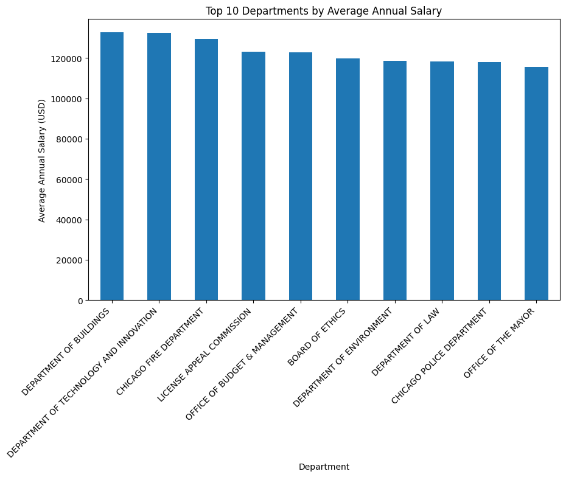

```python
# Calculate average salary for each department
avg_salary_dept = current.groupby('Department')['Annual Salary'].mean()

# Select the top 10 departments with the highest average salaries
top10 = avg_salary_dept.sort_values(ascending=False).head(10)

# Plot the results
plt.figure(figsize=(10,6))
top10.plot(kind='bar')

plt.title("Top 10 Departments by Average Annual Salary")
plt.ylabel("Average Annual Salary (USD)")
plt.xlabel("Department")
plt.xticks(rotation=45, ha='right')

plt.show()
```

### Analysis of Average Salary by Top 10 Department

These results reflect specialization within departments, showing that departments like the Board of Ethics, and Department of Buildings likely have more specialized positions that may require more training or more complex seniority levels.

```
Index(['Job Titles', 'Department', 'Salary or Hourly', 'Annual Salary',
       'Hourly Rate'],
      dtype='object')
```

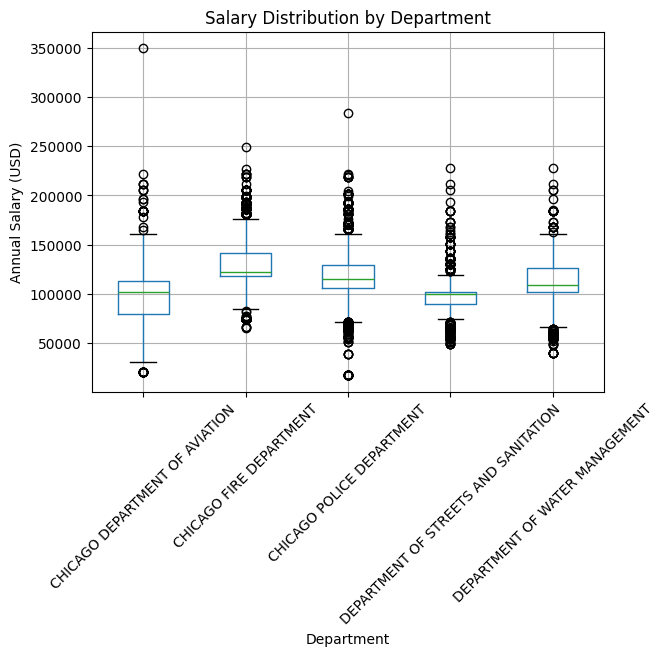

```python
#Boxplot of salary distributions for top departments
print(current.columns)
top_departments = current['Department'].value_counts().head(5).index


filtered = current[current['Department'].isin(top_departments)]

plt.figure(figsize=(12,6))

filtered.boxplot(
    column='Annual Salary',
    by='Department',
    rot=45
)

plt.title("Salary Distribution by Department")
plt.suptitle("")
plt.xlabel("Department")
plt.ylabel("Annual Salary (USD)")

plt.show()
```

### Analysis of Salary Distribution by Department

The Chicago Fire Department shows the highest median salary out of the departments analyzed, meaning there could be comparatively higher typical compensation levels, where as the Chicago Police Department demonstrates substantial salary variability, suggesting a wide range of positions, overtime structures, or ranks.

Overall, every department contains significant salary outliers, likely representing specialized roles, senior leadership, or employees with substantial overtime compensation.

### Loading Second Dataset:

```python
#Load the dataset
budget_df = pd.read_csv("/content/Budget_-_2026_Budget_Ordinance_-_Appropriations_20260426.csv")

#Inspect data types
print(budget_df.dtypes)

#Check missing values
print(budget_df.isnull().sum())

#Preview first 50 rows
budget_df.head(10)
```

```
FUND TYPE                              object
FUND CODE                              object
FUND DESCRIPTION                       object
DEPARTMENT NUMBER                       int64
DEPARTMENT DESCRIPTION                 object
APPROPRIATION AUTHORITY                object
APPROPRIATION AUTHORITY DESCRIPTION    object
APPROPRIATION ACCOUNT                  object
APPROPRIATION ACCOUNT DESCRIPTION      object
2026 ORDINANCE (AMOUNT $)              object
dtype: object
FUND TYPE                              0
FUND CODE                              0
FUND DESCRIPTION                       0
DEPARTMENT NUMBER                      0
DEPARTMENT DESCRIPTION                 0
APPROPRIATION AUTHORITY                0
APPROPRIATION AUTHORITY DESCRIPTION    0
APPROPRIATION ACCOUNT                  0
APPROPRIATION ACCOUNT DESCRIPTION      0
2026 ORDINANCE (AMOUNT $)              0
dtype: int64
```

|  | FUND TYPE | FUND CODE | FUND DESCRIPTION | DEPARTMENT NUMBER | DEPARTMENT DESCRIPTION | APPROPRIATION AUTHORITY | APPROPRIATION AUTHORITY DESCRIPTION | APPROPRIATION ACCOUNT | APPROPRIATION ACCOUNT DESCRIPTION | 2026 ORDINANCE (AMOUNT $) |
| --- | --- | --- | --- | --- | --- | --- | --- | --- | --- | --- |
| 0 | LOCAL | 0100 | Corporate Fund | 1 | Office of the Mayor | 2005 | Office of the Mayor | 0005 | Salaries and Wages - on Payroll | $10,707,977.00 |
| 1 | LOCAL | 0100 | Corporate Fund | 1 | Office of the Mayor | 2005 | Office of the Mayor | 0039 | For the Employment of Students as Trainees | $57,490.00 |
| 2 | LOCAL | 0100 | Corporate Fund | 1 | Office of the Mayor | 2005 | Office of the Mayor | 0126 | Office Conveniences | $1,500.00 |
| 3 | LOCAL | 0100 | Corporate Fund | 1 | Office of the Mayor | 2005 | Office of the Mayor | 0130 | Postage | $500.00 |
| 4 | LOCAL | 0100 | Corporate Fund | 1 | Office of the Mayor | 2005 | Office of the Mayor | 0140 | For Professional and Technical Services and Ot... | $12,000.00 |
| 5 | LOCAL | 0100 | Corporate Fund | 1 | Office of the Mayor | 2005 | Office of the Mayor | 0149 | For Software Maintenance and Licensing | $32,107.00 |
| 6 | LOCAL | 0100 | Corporate Fund | 1 | Office of the Mayor | 2005 | Office of the Mayor | 0157 | Rental of Equipment and Services | $500.00 |
| 7 | LOCAL | 0100 | Corporate Fund | 1 | Office of the Mayor | 2005 | Office of the Mayor | 0159 | Lease Purchase Agreements for Equipment and Ma... | $25,000.00 |
| 8 | LOCAL | 0100 | Corporate Fund | 1 | Office of the Mayor | 2005 | Office of the Mayor | 0162 | Repair/Maintenance of Equipment | $1,000.00 |
| 9 | LOCAL | 0100 | Corporate Fund | 1 | Office of the Mayor | 2005 | Office of the Mayor | 0166 | Dues, Subscriptions and Memberships | $225,094.00 |

### Budget Dataset Description

This dataset contains the 2026 Chicago Budget Ordinance appropriations by department.

Important variables include:

- `Department`: city department name
- `Total_budget`: total department funding allocated in the 2026 ordinance

This dataset allows us to compare departmental budgets with employee salary statistics to investigate whether larger budgets correspond to higher salaries or larger department sizes.

#### Data Inspection Interpretation

We see the dataset contains multiple columns reflecting how budgets are allocated across categories. Each row represents a part of a department's total budget. We also see that the ordinance value is stored as a string, which needs to be converted.

### Cleaning for Budget Dataset, and Additional Cleaning for Salary Dataset

Before aggregation and merge, we need to standardize both datasets for consistency. We do this by standardizing column names, converting any budget values from strings to numeric types, and handling any missing values. This step is necessary because the datasets come from different sources and have slightly different formats.

```python
#Perform Additional Cleaning on Salary Dataset (current):
#Standardize column names
current.columns = current.columns.str.lower().str.strip()

#Convert salary to numeric
current['annual salary'] = pd.to_numeric(current['annual salary'], errors='coerce')

#Drop missing values
current = current.dropna(subset=['annual salary'])

#Clean Budget Dataset (budget_df)
#Standardize column names
budget_df.columns = budget_df.columns.str.lower().str.strip()

#Remove $ and commas, and convert to numeric
budget_df['2026 ordinance (amount $)'] = (
    budget_df['2026 ordinance (amount $)']
    .replace('[\$,]', '', regex=True)
    .astype(float)
)

#Rename columns for consistency with salary dataset
budget_df = budget_df.rename(columns={
    'department description': 'department',
    '2026 ordinance (amount $)': 'total_budget'
})

#Drop missing values
budget_df = budget_df.dropna(subset=['total_budget'])

def clean_department(x):
  return(
      str(x)
      .lower()
      .strip()

      .replace("&", "and")
      .replace("'", "")
  )
current['department'] = current['department'].apply(clean_department)
budget_df['department'] = budget_df['department'].apply(clean_department)

#Map for any edge case departments that did not merge, but are the same in each set
mapping = {
    'department of administrative hearing' : 'department of administrative hearings'
}
#Apply mapping to both datasets
current['department'] = current['department'].replace(mapping)
budget_df['department'] = budget_df['department'].replace(mapping)

#Remove the non-department category, Finance General
budget_df = budget_df[budget_df['department'] !='finance general']

#Check missing values after cleaning
print(current.isnull().sum())
print(budget_df.isnull().sum())
```

```
job titles              0
department              0
salary or hourly        0
annual salary           0
hourly rate         24950
dtype: int64
fund type                              0
fund code                              0
fund description                       0
department number                      0
department                             0
appropriation authority                0
appropriation authority description    0
appropriation account                  0
appropriation account description      0
total_budget                           0
dtype: int64
```

### Data Aggregation

We know that the salary dataset records individual employee salaries and that our budget dataset records at the departmental level. In order to determine any relationships between departmental budgets and salaries, we need to aggregate salary data to departmental level. This will make the datasets comparable.

```python
#Aggregate Salary Data
salary_by_dep = current.groupby('department')['annual salary'].agg(
    avg_salary='mean',
    median_salary='median',
    salary_std='std',
    employee_count='count'
).reset_index()

#Aggregate the Budget Data
budget_by_dep = budget_df.groupby('department').agg(
    total_budget = ('total_budget', 'sum')
).reset_index()
```

### Merging the Datasets

After aggregating, we have both datasets at the departmental level. Now, we can merge both datasets using department as the merge key. Then we can begin analyzing any potential relationships.

```python
#Merge Datasets (Salary and Budget)
merged = pd.merge(
    salary_by_dep,
    budget_by_dep,
    on='department',
    how='inner'
)
#Make sure any departments with 1 employee and 0 as STDev are filled as NaN
print(merged.isnull().sum())
merged['salary_std'] = merged['salary_std'].fillna(0)

#Preview the merge
merged.head()
```

```
department        0
avg_salary        0
median_salary     0
salary_std        1
employee_count    0
total_budget      0
dtype: int64
```

|  | department | avg_salary | median_salary | salary_std | employee_count | total_budget |
| --- | --- | --- | --- | --- | --- | --- |
| 0 | board of election commissioners | 67616.701200 | 58092.0 | 25816.924751 | 100 | 2.786740e+07 |
| 1 | board of ethics | 119761.714286 | 122976.0 | 30859.853087 | 7 | 9.255970e+05 |
| 2 | chicago animal care and control | 81680.298507 | 73728.0 | 32305.420374 | 67 | 8.177388e+06 |
| 3 | chicago commission on human relations | 113735.368421 | 122700.0 | 26775.037770 | 19 | 2.773200e+06 |
| 4 | chicago department of aviation | 97601.272764 | 101358.4 | 29409.526824 | 1957 | 1.666094e+09 |

### EDA 1: Summary Statistics

We want to see the distribution of salaries, budgets, and employee counts across departments.

```python
merged.describe() #statistical summary of numerical columns in DF
```

|  | avg_salary | median_salary | salary_std | employee_count | total_budget |
| --- | --- | --- | --- | --- | --- |
| count | 39.000000 | 39.000000 | 39.000000 | 39.000000 | 3.900000e+01 |
| mean | 105453.897026 | 102834.091282 | 30754.191657 | 814.897436 | 2.686573e+08 |
| std | 16976.939890 | 17053.966691 | 8233.621098 | 2094.028261 | 5.192737e+08 |
| min | 64258.618307 | 58092.000000 | 0.000000 | 1.000000 | 2.099880e+05 |
| 25% | 97804.061382 | 93504.000000 | 26651.866487 | 56.000000 | 1.344046e+07 |
| 50% | 108675.082034 | 102672.000000 | 30859.853087 | 113.000000 | 3.936815e+07 |
| 75% | 115362.590909 | 114363.000000 | 35265.231303 | 600.500000 | 1.598674e+08 |
| max | 132624.287227 | 133431.960000 | 50538.896520 | 12336.000000 | 2.109812e+09 |

### Budget per Employee

We want to see the top departments by budget per employee.

```python
merged['budget_per_employee'] = (
    merged['total_budget'] / merged['employee_count']
) #ratio of budget per employee as a metric
merged.sort_values('budget_per_employee', ascending=False).head(10) #Add in
```

|  | department | avg_salary | median_salary | salary_std | employee_count | total_budget | budget_per_employee |
| --- | --- | --- | --- | --- | --- | --- | --- |
| 19 | department of environment | 118482.240000 | 107628.0 | 30315.868542 | 25 | 5.245890e+07 | 2.098356e+06 |
| 23 | department of housing | 96639.527273 | 93504.0 | 32444.736657 | 110 | 1.732520e+08 | 1.575018e+06 |
| 6 | chicago department of transportation | 111859.438574 | 106912.0 | 21379.502975 | 1318 | 1.837523e+09 | 1.394175e+06 |
| 20 | department of family and support services | 64258.618307 | 76464.0 | 50538.896520 | 579 | 6.533660e+08 | 1.128439e+06 |
| 18 | department of cultural affairs and special events | 106696.645161 | 105684.0 | 34560.747739 | 62 | 6.200360e+07 | 1.000058e+06 |
| 26 | department of planning and development | 109732.490798 | 102144.0 | 29260.192635 | 163 | 1.464828e+08 | 8.986676e+05 |
| 4 | chicago department of aviation | 97601.272764 | 101358.4 | 29409.526824 | 1957 | 1.666094e+09 | 8.513508e+05 |
| 29 | department of technology and innovation | 132525.625000 | 129738.0 | 32523.528336 | 96 | 7.638304e+07 | 7.956567e+05 |
| 33 | office of budget and management | 122866.800000 | 120312.0 | 41883.942900 | 50 | 3.855270e+07 | 7.710540e+05 |
| 22 | department of fleet and facility management | 113675.859930 | 120120.0 | 23774.700500 | 863 | 5.034541e+08 | 5.833767e+05 |

#### Table Interpretation:

The table above shows the departments that have the highest budget per employee, which reflects how the resources are spread relative to the size of the department.

Other departments, such as Housing and Transportation also have high budget per employee values, which can also reflect the of these departments, for example, public services, maintenence, and and likely large projects.

Overall, this reveals that budget allocation is not just determined by the size of the department or the salaries, but also what kind of projects and services these departments require, which will increase the amount of funding per employee budgeted for the year.

### Does Department Size Determine Budget?

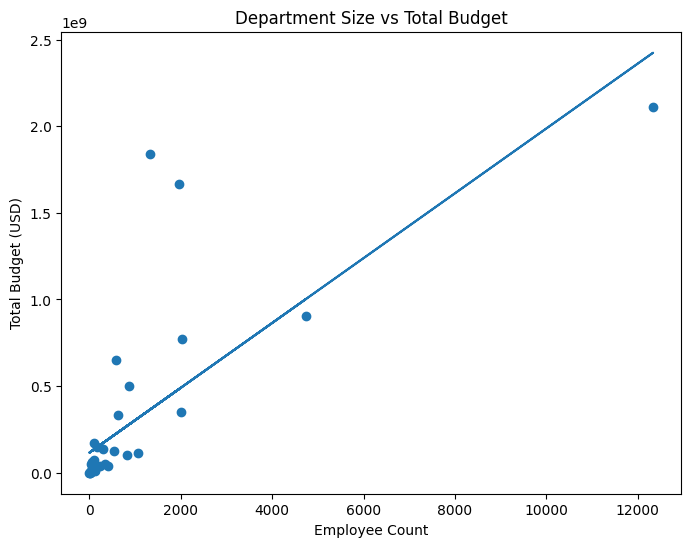

```python
#scatterplot of total budget v. department size
plt.figure(figsize=(8,6))

plt.scatter(
    merged['employee_count'],
    merged['total_budget']
)

#trendline
z = np.polyfit(merged['employee_count'], merged['total_budget'], 1)
p = np.poly1d(z)

plt.plot(
    merged['employee_count'],
    p(merged['employee_count'])
)

plt.title("Department Size vs Total Budget")
plt.xlabel("Employee Count")
plt.ylabel("Total Budget (USD)")

plt.show()
```

#### Interpretation of Employee Count versus Total Budget

In this scatter plot, we can see that the two variables are positively correlated. As the employee count increases, so does the total budget. This indicates that the size of the department is a determinant of the budget that department will get.

Although there is an upward trend, its not linear. Even departments with similar employee counts will have different budgets, again, suggesting that budget is also impacted by other factors previously mentioned.

Overall, this analysis shows that department size is a key driver of the total budget received by the department, but that there are other factors that also determine it.

### Efficiency versus Pay

Now that we have determined that salary does not determine budget and that size does play a role, we can see if high-spending departments are actually paying their employees more or if this money is going elsewhere.

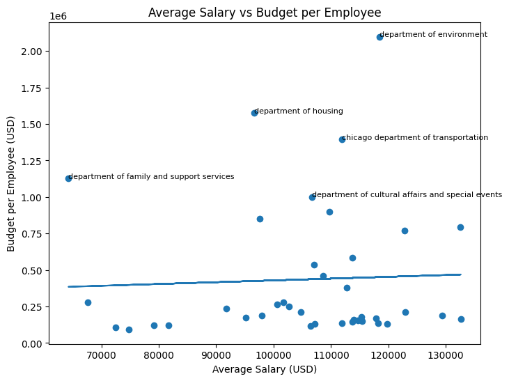

```python
#scatter plot comparing avg salary and budget per employee
plt.figure(figsize=(8,6))

plt.scatter(
    merged['avg_salary'],
    merged['budget_per_employee']
)

#trendline
z = np.polyfit(merged['avg_salary'], merged['budget_per_employee'], 1)
p = np.poly1d(z)

plt.plot(
    merged['avg_salary'],
    p(merged['avg_salary'])
)

plt.title("Average Salary vs Budget per Employee")
plt.xlabel("Average Salary (USD)")
plt.ylabel("Budget per Employee (USD)")

#label outliers
for i, row in merged.iterrows():
    if row['budget_per_employee'] > 1000000:
        plt.text(
            row['avg_salary'],
            row['budget_per_employee'],
            row['department'],
            fontsize=8
        )

plt.show()
```

#### Average Salary vs Budget per Employee Interpretation

This plot compares the average salary to the budget per employee, which reveals how departments use their resources relative to employee compensation.

Most of the departments cluster together with lower budget per employee, which shows that the spending money is mainly being used toward employee salaries. From this, it can be inferred that departments in this group are more labor-focused. In contrast, the few departments that have higher budget per employee with similar salary levels indicate other non-salary factors. This means that these departments likely require resources that their budget also goes toward.

The clear outlier here, the Department of Environment, which we have seen in our previous analysis, has an exceptionally high budget per employee. Again, confirming that this department spends budget on more than just compensation.

### EDA Summary:

From analysis, we gather the following conclusions:

- There is no strong relationship between the average salary and the budget per employee
- A positive relationship exists between the employee count and the total budget per department
- There is low variance in salaries across departments and high variance in budget and employee count
- Department of Environment constantly shows up as an outlier

Ultimately, our analysis shows us that salary is not a good predictive feature of budget while the department size is a good predictor. We also get a further understanding of the budget distribution, inferring that some departments consider other resrouces when accounting for the budget per employee. This informs our decision of what type of model we want to make, as we originally thought to use salary as a prediction of budget, but now realize this is unideal.

### Multiple Linear Regression Model - Outline

What will a department's budget be based on the number of employees and the average and median employee salary.

We will build a Multiple Linear Regression Model with the following parameters:

Target (Y): -total_budget

Predictor Variables:  
-employee_count (this will be our primary predictor due to its strong relationship found in our analysis) -avg_salary -median_salary

From our analysis, we gathered that there was a positive relationship between employee count and total budget, showing that department size is a key feature in driving departmental spending. We also saw that salary variables had weak relationships with budget per employee, but potentially, when combined with other features, contribute to the prediction.

We chose a multiple linear regression model because total_budget is a continuous variable and the relationships between variables show some linearity. Ultimately, we want to quantify the impact of each of the predictor variables.

From our model, we expect the employee count to dominate.

Outline of Steps:

```
Multiple Linear Regression Results
R²: 0.14169855909622653
RMSE: 674124080.0238918
MAE: 411196247.41025555

Cross-Validation R² Scores: [  0.1689401    0.21169543 -12.22204202   0.62798257  -4.52814009]
Average CV R²: -3.1483128000746126
```

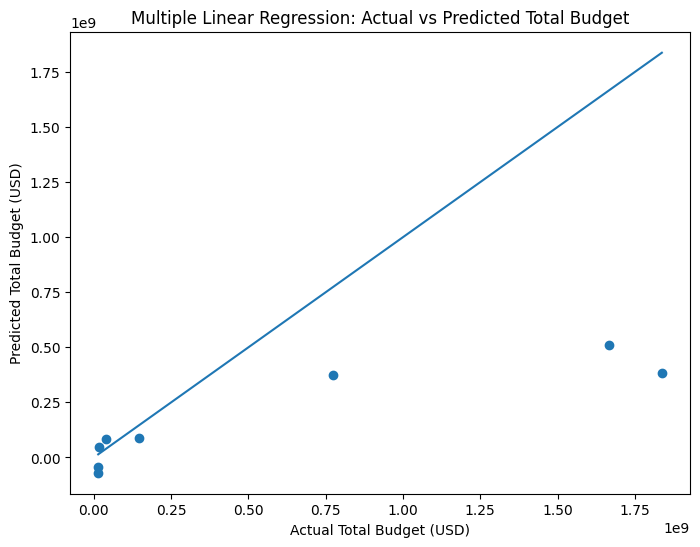

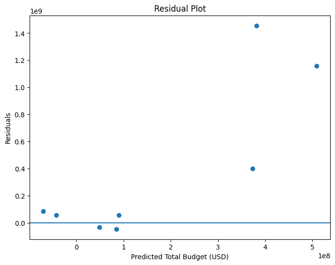

```python
# Import libraries
from sklearn.model_selection import train_test_split, cross_val_score
from sklearn.preprocessing import StandardScaler
from sklearn.pipeline import make_pipeline
from sklearn.linear_model import LinearRegression
from sklearn.metrics import mean_squared_error, mean_absolute_error, r2_score

# Features and target
X = merged[['employee_count', 'avg_salary', 'median_salary', 'budget_per_employee']]
y = merged['total_budget']

# Split the data
X_train, X_test, y_train, y_test = train_test_split(
    X,
    y,
    test_size=0.2,
    random_state=42
)

# Create pipeline with scaling + regression
model = make_pipeline(
    StandardScaler(),
    LinearRegression()
)

# Train the model
model.fit(X_train, y_train)

# Predictions
y_pred = model.predict(X_test)

# Metrics
r2 = r2_score(y_test, y_pred)
rmse = np.sqrt(mean_squared_error(y_test, y_pred))
mae = mean_absolute_error(y_test, y_pred)

# Print results
print("Multiple Linear Regression Results")
print("R²:", r2)
print("RMSE:", rmse)
print("MAE:", mae)

# Cross-validation
cv_scores = cross_val_score(
    model,
    X,
    y,
    cv=5,
    scoring='r2'
)

print("\nCross-Validation R² Scores:", cv_scores)
print("Average CV R²:", cv_scores.mean())

# Actual vs predicted plot

plt.figure(figsize=(8,6))

plt.scatter(y_test, y_pred)

# Perfect prediction line
plt.plot(
    [y_test.min(), y_test.max()],
    [y_test.min(), y_test.max()]
)

plt.title("Multiple Linear Regression: Actual vs Predicted Total Budget")
plt.xlabel("Actual Total Budget (USD)")
plt.ylabel("Predicted Total Budget (USD)")

plt.show()

# Residual plot

residuals = y_test - y_pred

plt.figure(figsize=(8,6))

plt.scatter(y_pred, residuals)

plt.axhline(y=0)

plt.title("Residual Plot")
plt.xlabel("Predicted Total Budget (USD)")
plt.ylabel("Residuals")

plt.show()
```

### Multiple Linear Regression Model Analysis

The improved multiple linear regression model was used to predict departmental budgets using employee count, average salary, median salary, and budget per employee. Standardization was applied to reduce the impact of differing variable scales, and 5-fold cross-validation was incorporated to evaluate model generalizability. The scatterplot comparing actual and predicted departmental budgets shows that the model captures some overall trends in departmental funding, although prediction errors remain substantial for several departments. Larger departments with exceptionally high budgets were more difficult for the model to accurately predict, implying the presence of nonlinear relationships or omitted variables.

The residual plot further shows variability in prediction accuracy. Residuals are not evenly distributed around zero, indicating that the model may not fully capture the complexity of budgeting structures. Departments with specialized operational costs or unusually large expenditures likely contribute to these inconsistencies. Cross-validation results provide additional evidence regarding model stability. While some predictive relationship exists between salary metrics and departmental budgets, the weak R² values suggest that budget allocation depends on many additional factors beyond employee compensation alone. Variables such as equipment costs and public safety funding not represented in the dataset.

### K-Nearest Neighbors (KNN) Regression Model - Outline

To improve our analysis, we implemented a K-Nearest Neighbors (KNN) regression model. KNN predicts values by examining the most similar observations in the dataset based on feature similarity. Unlike linear regression, KNN does not assume a linear relationship between variables, making it useful for detecting more complex patterns in departmental salary and budget data.

The model uses:

- employee count
- average salary
- median salary
- salary standard deviation

to predict budget per employee for each department.

```
KNN Regression Results
R²: -0.57452942078056
RMSE: 541754.3546248741
MAE: 439374.17510046496
```

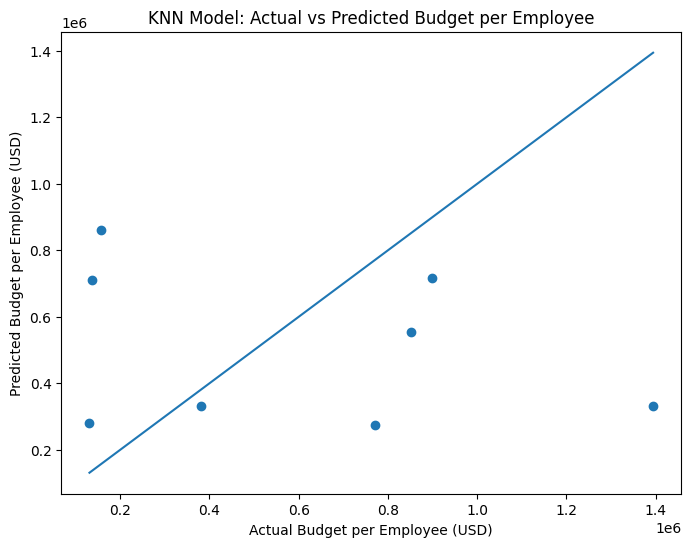

```
Cross-Validation R² Scores: [ -0.29870608 -69.11215192  -0.773308    -0.74804987  -1.11252087]
Average CV R²: -14.408947346532258
```

```python
# Import libraries
from sklearn.model_selection import train_test_split
from sklearn.preprocessing import StandardScaler
from sklearn.neighbors import KNeighborsRegressor
from sklearn.metrics import mean_squared_error, mean_absolute_error, r2_score

# Features and target
X = merged[['employee_count', 'avg_salary', 'median_salary', 'salary_std']]
y = merged['budget_per_employee']

# Train/test split
X_train, X_test, y_train, y_test = train_test_split(
    X,
    y,
    test_size=0.2,
    random_state=42
)

# Scale the data
scaler = StandardScaler()

X_train_scaled = scaler.fit_transform(X_train)
X_test_scaled = scaler.transform(X_test)

# Create KNN model
knn = KNeighborsRegressor(n_neighbors=5)

# Train model
knn.fit(X_train_scaled, y_train)

# Predictions
y_pred = knn.predict(X_test_scaled)

# Evaluation metrics
rmse = np.sqrt(mean_squared_error(y_test, y_pred))
mae = mean_absolute_error(y_test, y_pred)
r2 = r2_score(y_test, y_pred)

# Print results
print("KNN Regression Results")
print("R²:", r2)
print("RMSE:", rmse)
print("MAE:", mae)

# Plot predicted vs actual values

plt.figure(figsize=(8,6))

plt.scatter(y_test, y_pred)

# Perfect prediction reference line
plt.plot(
    [y_test.min(), y_test.max()],
    [y_test.min(), y_test.max()]
)

plt.title("KNN Model: Actual vs Predicted Budget per Employee")
plt.xlabel("Actual Budget per Employee (USD)")
plt.ylabel("Predicted Budget per Employee (USD)")

plt.show()

from sklearn.model_selection import cross_val_score

# Perform 5-fold cross-validation
cv_scores = cross_val_score(
    knn,
    scaler.fit_transform(X),
    y,
    cv=5,
    scoring='r2'
)

print("Cross-Validation R² Scores:", cv_scores)
print("Average CV R²:", cv_scores.mean())
```

### KNN Regression Model Analysis

The KNN regression model produced relatively weak predictive performance when estimating budget per employee using departmental salary statistics and employee counts. The model resulted in an R² value of approximately -0.57, indicating that the model performed worse than simply predicting the average value across all departments. Additionally, the RMSE and MAE values were large, suggesting prediction error between actual and predicted budget.

The results suggest that departmental budgets are influenced by many additional factors not included in this analysis, such as operational costs, infrastructure expenses, overtime, equipment needs, public safety funding, and administrative priorities. Overall, the KNN model demonstrates that salary-related variables alone are insufficient for accurately predicting budget allocation patterns across Chicago departments.

### Model Comparsion

The multiple linear regression model assumes a linear relationship between the independent variables and the target variable. Linear regression is highly interpretable, allowing us to understand how each feature contributes to budget predictions. The model was able to capture some broad trends in departmental funding, but prediction accuracy remained limited, especially for departments with exceptionally large budgets or unusual operational structures. On the other hand, the KNN regression model does not assume a linear relationship between variables and can potentially capture more complex patterns. However, because the dataset contained relatively few departments and several extreme outliers, the KNN model performed poorly and struggled to generalize during cross-validation. The model was highly sensitive to the structure of the data and produced unstable predictions across folds.

Overall, the multiple linear regression model performed better in terms of interpretability and consistency, while the KNN model demonstrated the limitations of non-parametric methods on small datasets with high variability. Both models suggest that salary and workforce characteristics alone are insufficient for accurately predicting municipal budgets. Additional variables such as infrastructure costs, overtime, capital projects, public safety expenditures, and administrative priorities would likely improve predictive performance in future analyses.

```python
model_results = pd.DataFrame({
    'Model': ['Multiple Linear Regression', 'KNN Regression'],
    'Target Variable': ['Total Budget', 'Budget per Employee'],
    'Main Strength': [
        'Easy to interpret relationships between variables',
        'Can capture non-linear patterns'
    ],
    'Main Weakness': [
        'Struggles with outliers and non-linear budgeting patterns',
        'Performs poorly with small datasets'
    ]
})

model_results
```

|  | Model | Target Variable | Main Strength | Main Weakness |
| --- | --- | --- | --- | --- |
| 0 | Multiple Linear Regression | Total Budget | Easy to interpret relationships between variables | Struggles with outliers and non-linear budgeti... |
| 1 | KNN Regression | Budget per Employee | Can capture non-linear patterns | Performs poorly with small datasets |

## Data Limitations

This analysis has several limitations. First, the salary dataset captures employee compensation but does not include all possible costs that affect departmental budgets, such as equipment, facilities, infrastructure, contracted services, benefits, or overtime categories. Second, after aggregation, the model operates at the department level, which creates a relatively small dataset. This limits machine learning performance and makes the models sensitive to outliers. Third, some departments may have unique responsibilities that make direct comparison difficult. For example, Aviation and Water Management likely require large infrastructure budgets that are not explained by salaries alone.

## Final Conclusion

In conclusion, the analysis shows that salary patterns and employee counts provide some insight into Chicago departmental budgeting, but they do not fully explain budget allocation. EDA revealed meaningful differences in salary distributions across departments, especially through median salaries, percentiles, and outliers. The Fire and Police Departments showed relatively high salary levels, while departments such as Aviation and Water Management demonstrated that large budgets may be driven by infrastructure and operational costs rather than salary alone. The modeling results support this conclusion. The multiple linear regression and KNN models both struggled to make consistently accurate predictions, especially for departments with unusually large budgets. This suggests that department budgets are shaped by more than workforce size and employee compensation. Future analysis would be stronger if it included overtime, benefits, capital spending, equipment costs, and service-level demand.

## Further Resources

- City of Chicago Data Portal: public datasets on salaries, budgets, departments, and city operations.
- Pandas Documentation: useful for cleaning, grouping, and merging datasets.
- Scikit-learn Documentation: useful for regression models, KNN, scaling, and cross-validation.
- Matplotlib Documentation: useful for improving graph labels, titles, and visual clarity.

### Sources

City of Chicago Employee Salary Dataset https://catalog.data.gov/dataset/current-employee-names-salaries-and-position-titles

Budget-2026 Budget Ordinance-Appropriations (City of Chicago) https://data.cityofchicago.org/Administration-Finance/Budget-2026-Budget-Ordinance-Appropriations/6694-f78c/data_preview

Libraries used:

- Python
- matplotlib
- numpy

Google Colab documentation https://colab.research.google.com/

### Exporting the Notebook

Finally, we convert our notebook to HTML and export it so we can upload it to our github.

```python
#!jupyter nbconvert --to html Milestone_2-2.ipynb
#files.download("Milestone_2-2.html")
```